# (PISA 2012)

PISA is a unique global survey that examines how well prepared 15 year old students are for life after they have completed school. Approximately a half million students and 65 economies participated in this assessment that deals with reading, math, and science literacy.

## Preliminary Wrangling

> Since the data is too large, after opening pisa2012.csv from Excel and reading the description of the field, I only select some features to observe the data.

```python
# import all packages and set plots to be embedded inline
import numpy as np
import pandas as pd
import matplotlib.pyplot as plt
import seaborn as sb

%matplotlib inline
```

> Load in your dataset and describe its properties through the questions below. Try and motivate your exploration goals through this section.

```python
df= pd.read_csv('pisa2012.csv')
df.head()
```

|  | CNT | ST03Q01 | ST04Q01 | ST11Q01 | ST11Q02 | AGE | COBN_F | COBN_M | PV1MATH | PV2MATH | ... | PV1READ | PV2READ | PV3READ | PV4READ | PV5READ | PV1SCIE | PV2SCIE | PV3SCIE | PV4SCIE | PV5SCIE |
| --- | --- | --- | --- | --- | --- | --- | --- | --- | --- | --- | --- | --- | --- | --- | --- | --- | --- | --- | --- | --- | --- |
| 0 | Albania | 2 | Female | Yes | Yes | 16.17 | Albania | Albania | 406.8469 | 376.4683 | ... | 249.5762 | 254.3420 | 406.8496 | 175.7053 | 218.5981 | 341.7009 | 408.8400 | 348.2283 | 367.8105 | 392.9877 |
| 1 | Albania | 2 | Female | Yes | Yes | 16.17 | Albania | Albania | 486.1427 | 464.3325 | ... | 406.2936 | 349.8975 | 400.7334 | 369.7553 | 396.7618 | 548.9929 | 471.5964 | 471.5964 | 443.6218 | 454.8116 |
| 2 | Albania | 9 | Female | Yes | Yes | 15.58 | Albania | Albania | 533.2684 | 481.0796 | ... | 401.2100 | 404.3872 | 387.7067 | 431.3938 | 401.2100 | 499.6643 | 428.7952 | 492.2044 | 512.7191 | 499.6643 |
| 3 | Albania | 8 | Female | Yes | Yes | 15.67 | Albania | Albania | 412.2215 | 498.6836 | ... | 547.3630 | 481.4353 | 461.5776 | 425.0393 | 471.9036 | 438.6796 | 481.5740 | 448.9370 | 474.1141 | 426.5573 |
| 4 | Albania | 10 | Female | Yes | Yes | 15.50 | Albania | Albania | 381.9209 | 328.1742 | ... | 311.7707 | 141.7883 | 293.5015 | 272.8495 | 260.1405 | 361.5628 | 275.7740 | 372.7527 | 403.5248 | 422.1746 |

5 rows × 23 columns

```python
df.shape
```

```
(485490, 23)
```

there are 5 plausible scores of performance recorded for a student. We will compute the actual score of the student by taking the average of the 5 plausible scores, as performed below:

```python
# Compute the average of plausible scores determines the PISA score of a student in a particular subject

df['Math Score'] = (df['PV1MATH'] + df['PV2MATH'] + df['PV3MATH'] + df['PV4MATH'] + df['PV5MATH']) / 5
df['Reading Score'] = (df['PV1READ'] + df['PV2READ'] + df['PV3READ'] + df['PV4READ'] + df['PV5READ']) / 5
df['Science Score'] = (df['PV1SCIE'] + df['PV2SCIE'] + df['PV3SCIE'] + df['PV4SCIE'] + df['PV5SCIE']) / 5
```

```python
#Remove the original field

df.drop(columns = ['PV1MATH', 'PV2MATH', 'PV3MATH', 'PV4MATH', 'PV5MATH', 'PV1READ', 'PV2READ', 'PV3READ', 'PV4READ',
                   'PV5READ','PV1SCIE', 'PV2SCIE', 'PV3SCIE', 'PV4SCIE', 'PV5SCIE'], inplace = True)
```

```python
# Rename columns appropriately

df.rename({'CNT' : 'Country', 'ST03Q01' : 'Birth month', 'ST04Q01' : 'Gender', 'AGE' : 'Age', 'COBN_F' : 'Birth Country Father',
           'COBN_M' : 'Birth Country Mother', 'ST11Q01' : 'Mother at Home', 'ST11Q02' : 'Father at Home'}, axis = 'columns', inplace = True)
```

```python
df.info()
```

```
<class 'pandas.core.frame.DataFrame'>
RangeIndex: 485490 entries, 0 to 485489
Data columns (total 11 columns):
 #   Column                Non-Null Count   Dtype
---  ------                --------------   -----
 0   Country               485490 non-null  object
 1   Birth month           485490 non-null  int64
 2   Gender                485490 non-null  object
 3   Mother at Home        460559 non-null  object
 4   Father at Home        441036 non-null  object
 5   Age                   485374 non-null  float64
 6   Birth Country Father  481825 non-null  object
 7   Birth Country Mother  481843 non-null  object
 8   Math Score            485490 non-null  float64
 9   Reading Score         485490 non-null  float64
 10  Science Score         485490 non-null  float64
dtypes: float64(4), int64(1), object(6)
memory usage: 40.7+ MB
```

The following amendments are made to the country name. The revised principle is:

Query [Country codes according to ISO-3166] (https://laendercode.net/en/) to confirm unfamiliar country abbreviations and indicate them by full name If the name of a particular country is revised to the country's abbreviation, if the special city education is independent of the country as a whole, then the city name Unknown if the name is displayed as a regional place name (for example: Latin America)

```python
def modify_country_names(item):
    """
    This function will correct the country abbreviations and different names
    but actually the name of the same country
    """

    item = item.strip()
    if item.find('United Kingdom') != -1:
        return 'UK'
    elif item.find('United States') != -1:
        return 'USA'
    elif item.find('United States of America') != -1:
        return 'USA'
    elif item.find('Another American country [URY]') != -1:
        return 'Uruguay'
    elif item.find('Another country within the European Union (ITA)') != -1:
        return 'Italy'
    elif item.find('Another province in mainland China (QCN)') != -1:
        return 'China'
    elif item.lower().find('another country (') != -1:
        if item[17:20] == 'QUK':
            return 'Unknown'
        if item[17:20] == 'QSC':
            return 'Unknown'
        if item[17:20] == 'QCN':
            return 'China'
        if item[17:20] == 'TAP':
            return 'Myanmar'
        if item[17:20] == 'NLD':
            return 'Netherlands'
        return item[17:20]
    if item.find('ARE') != -1:
        return 'United Arab Emirates'
    elif item.find('ESP') != -1:
        return 'Spain'
    elif item.find('PRT') != -1:
        return 'Portugal'
    elif item.find('Other European country (NLD)') != -1:
        return 'Netherlands'
    elif item.find('Slovak Republic') != -1:
        return 'Slovakia'
    elif item.find('LUX') != -1:
        return 'Luxembourg'
    elif item.find('Hong Kong') != -1:
        return 'Hong Kong'
    elif item.find('QSC') != -1:
        return 'Unknown'
    elif item.find('An Eastern European country') != -1:
        return 'Unknown'
    elif item.find('A European country') != -1:
        return 'Unknown'
    elif item.find('An Eastern European country outside the EU') != -1:
        return 'Unknown'
    elif item.find('A Sub-Saharan country (Africa excl. Maghreb)') != -1:
        return 'Unknown'
    elif item.find('Serbia, Montenegro and Kosovo') != -1:
        return 'Serbia'
    elif item.find('In another former USSR republic (KAZ)') != -1:
        return 'Kazakhstan'
    elif item.find('Macao') != -1:
        return 'China'
    elif item.find('China') != -1:
        return 'China'
    elif item.find('United States') != -1:
        return 'USA'
    elif item.find('South, Latin  and Central America') != -1:
        return 'Unknown'
    elif item.find('African country with Portuguese as the official') != -1:
        return 'Lusophone Africa'
    elif item.find('Bolivia (Plurinational State of)') != -1:
        return 'Bolivia'
    elif item.find('Invalid') != -1:
        return 'Unknown'
    elif item.find('Middle Eastern country') != -1:
        return 'Unknown'
    elif item == 'Chinese Taipei':
        return 'Taiwan'
    elif item == 'Africa':
        return 'Unknown'
    elif item == 'Czechia':
        return 'Czech Republic'
    elif item == 'United Arab Emirates':
        return 'UAE'
    elif item == 'Russian Federation':
        return 'Russia'
    elif item == 'Republic of Korea':
        return 'Korea'
    elif item == 'Iran, Islamic Republic of':
        return 'Iran'
    elif item == 'Netherlands Antilles':
        return 'Netherlands'
    elif item == 'Missing':
        return 'Unknown'
    elif item == 'Occupied Palestinian Territory':
        return 'Unknown'
    elif item == 'nan':
        return 'Unknown'
    elif len(item) > 30:
        return 'Unknown'
    return item
```

```python
# Uniform country name
df = df.replace(['Connecticut (USA)', 'Florida (USA)', 'Massachusetts (USA)', 'United States of America'], 'USA')
df = df.replace(['Perm(Russian)', 'Russian Federation', 'Perm(Russian Federation)'], 'Russia')
df = df.replace('United Kingdom', 'UK')
df = df.replace('United Arab Emirates', 'UAE')
df = df.replace(['China-Shanghai'], 'China')
df = df.replace(['Hong Kong-China'], 'Hong Kong')
df = df.replace('Chinese Taipei', 'Taiwan')
df = df.replace('United States', 'USA')
df = df.replace('Korea, Republic of', 'Korea')
df = df.replace('Czechia', 'Czech')
df = df.replace('Czech Republic', 'Czech')
df = df.replace('Hong Kong-China', 'Hong Kong')
df = df.replace('Macao-China', 'China')
df = df.replace('Slovak Republic', 'Slovakia')
df = df.replace('Macao', 'China')
df = df.replace('Bosnia and Herzegovina', 'Bosnia')
```

```python
# apply the defined function for all names of countries
df['Country'] = df['Country'].astype(str)
df['Country'] = df['Country'].apply(modify_country_names)
df['Birth Country Mother'] = df['Birth Country Mother'].astype(str)
df['Birth Country Mother'] = df['Birth Country Mother'].apply(modify_country_names)
df['Birth Country Father'] = df['Birth Country Father'].astype(str)
df['Birth Country Father'] = df['Birth Country Father'].apply(modify_country_names)
```

Since we want to know if the presence of parents at home is a factor that affects the student score, we will add a new cloum to describe it.

```python
#Sum the values of Mother at Home and Father at Home
# 0: Representing parents are not at home
# 1: Representing one of the parents at home
# 2: Both parents are at home
df['Mother at Home'].fillna('Yes', inplace=True)
df['Mother at Home'].replace({'No': 0, 'Yes': 1}, inplace=True)
df['Father at Home'].fillna('Yes', inplace=True)
df['Father at Home'].replace({'No': 0, 'Yes': 1}, inplace=True);
```

```python
df['Parent at home'] = df['Mother at Home'] + df['Father at Home']
```

```python
# Convert values to descriptive text
df['Parent at home'] = df['Parent at home'].replace({0: 'None', 1: 'One', 2: 'Both'})
```

```python
#Remove the original field
df.drop(columns=['Mother at Home', 'Father at Home'], inplace=True)
```

```python
df.head()
```

|  | Country | Birth month | Gender | Age | Birth Country Father | Birth Country Mother | Math Score | Reading Score | Science Score | Parent at home |
| --- | --- | --- | --- | --- | --- | --- | --- | --- | --- | --- |
| 0 | Albania | 2 | Female | 16.17 | Albania | Albania | 366.18634 | 261.01424 | 371.91348 | Both |
| 1 | Albania | 2 | Female | 16.17 | Albania | Albania | 470.56396 | 384.68832 | 478.12382 | Both |
| 2 | Albania | 9 | Female | 15.58 | Albania | Albania | 505.53824 | 405.18154 | 486.60946 | Both |
| 3 | Albania | 8 | Female | 15.67 | Albania | Albania | 449.45476 | 477.46376 | 453.97240 | Both |
| 4 | Albania | 10 | Female | 15.50 | Albania | Albania | 385.50398 | 256.01010 | 367.15778 | Both |

Since we need to find out whether a student comes from a homogenous or heterogenous family background, we will perform feature engineering to create a variable which tells us this information.

```python
df['Parents - Same Cultural Background'] = (df['Birth Country Father'] == df['Birth Country Mother'])

df.loc[df['Parents - Same Cultural Background'] == True, 'Parents - Same Cultural Background'] = 'Same'
df.loc[df['Parents - Same Cultural Background'] == False, 'Parents - Same Cultural Background'] = 'Different'

#Remove the original field
df.drop(columns=['Birth Country Father', 'Birth Country Mother'], inplace=True)

df.head()
```

|  | Country | Birth month | Gender | Age | Math Score | Reading Score | Science Score | Parent at home | Parents - Same Cultural Background |
| --- | --- | --- | --- | --- | --- | --- | --- | --- | --- |
| 0 | Albania | 2 | Female | 16.17 | 366.18634 | 261.01424 | 371.91348 | Both | Same |
| 1 | Albania | 2 | Female | 16.17 | 470.56396 | 384.68832 | 478.12382 | Both | Same |
| 2 | Albania | 9 | Female | 15.58 | 505.53824 | 405.18154 | 486.60946 | Both | Same |
| 3 | Albania | 8 | Female | 15.67 | 449.45476 | 477.46376 | 453.97240 | Both | Same |
| 4 | Albania | 10 | Female | 15.50 | 385.50398 | 256.01010 | 367.15778 | Both | Same |

```python
df.Age.value_counts()
```

```
15.58    42762
15.67    42353
15.75    41664
15.83    41402
15.92    41084
16.00    41049
15.42    40437
15.50    40291
16.08    39313
16.17    38356
15.33    28354
16.25    26139
15.25    11986
16.33    10183
15.17        1
Name: Age, dtype: int64
```

Because age is approximately the same i will drop it

```python
df.drop(columns='Age', inplace=True)
```

```python
print(df.shape)
df.head()
```

```
(485490, 8)
```

|  | Country | Birth month | Gender | Math Score | Reading Score | Science Score | Parent at home | Parents - Same Cultural Background |
| --- | --- | --- | --- | --- | --- | --- | --- | --- |
| 0 | Albania | 2 | Female | 366.18634 | 261.01424 | 371.91348 | Both | Same |
| 1 | Albania | 2 | Female | 470.56396 | 384.68832 | 478.12382 | Both | Same |
| 2 | Albania | 9 | Female | 505.53824 | 405.18154 | 486.60946 | Both | Same |
| 3 | Albania | 8 | Female | 449.45476 | 477.46376 | 453.97240 | Both | Same |
| 4 | Albania | 10 | Female | 385.50398 | 256.01010 | 367.15778 | Both | Same |

### What is the structure of your dataset?

> There are 485,490 students in the dataset with 8 features

### What is/are the main feature(s) of interest in your dataset?

> iam interseted in seein the influence of seasonal birth, gender,Parents' existence at home and a homogenous or heterogenous family background in student's perform in math, reading and science.

> Also iam carious about which countries have students with exceptionally high literacy scores

## Univariate Exploration

> In this section, investigate distributions of individual variables.

```python
df.describe()
```

|  | Birth month | Math Score | Reading Score | Science Score |
| --- | --- | --- | --- | --- |
| count | 485490.000000 | 485490.000000 | 485490.000000 | 485490.000000 |
| mean | 6.558512 | 469.651234 | 472.006964 | 475.808094 |
| std | 3.705244 | 100.786610 | 98.863310 | 97.998470 |
| min | 1.000000 | 54.767080 | 6.445400 | 25.158540 |
| 25% | 4.000000 | 396.019620 | 405.044200 | 405.762800 |
| 50% | 7.000000 | 465.734520 | 475.477980 | 475.512860 |
| 75% | 9.000000 | 540.123060 | 542.831195 | 546.381920 |
| max | 99.000000 | 903.107960 | 849.359740 | 857.832900 |

### Scores

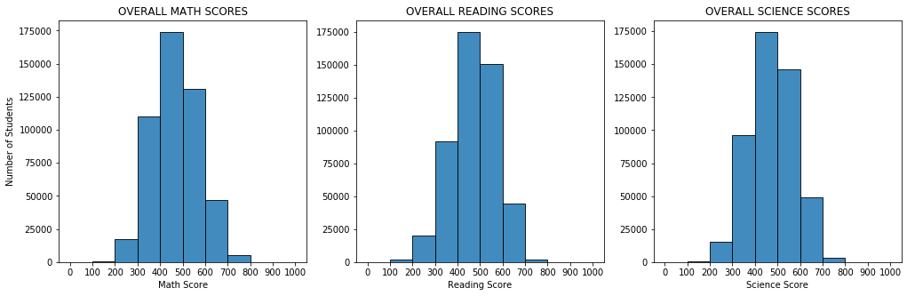

```python
plt.figure(figsize = [17, 5])

bins = np.arange(0, 1000 + 100, 100)

plt.subplot(1, 3, 1)
plt.hist(df['Math Score'], bins = bins, ec = 'black', alpha = 0.85);

plt.xticks(bins)
plt.xlabel('Math Score');
plt.ylabel('Number of Students')
plt.title("OVERALL MATH SCORES");

plt.subplot(1, 3, 2)
plt.hist(df['Reading Score'], bins = bins, ec = 'black', alpha = 0.85);

plt.xticks(bins)
plt.xlabel('Reading Score');
plt.title("OVERALL READING SCORES");

plt.subplot(1, 3, 3)
plt.hist(df['Science Score'], bins = bins, ec = 'black', alpha = 0.85);

plt.xticks(bins)
plt.xlabel('Science Score');
plt.title("OVERALL SCIENCE SCORES");
```

> All scores are spread out in unimodal distribution of values with a peak 500 The majority of the students are scoring in each subject between 300 and 600 points, while a small number of students are scoring (between 100 and 300 points) or greater (between 600 and 800 points) test performance

### Gender

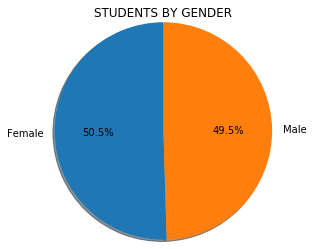

```python
fig1, ax1 = plt.subplots()
ax1.pie(df['Gender'].value_counts(), labels=df['Gender'].value_counts().index, autopct='%1.1f%%',shadow=True, startangle=90,radius=1.25);
plt.title('STUDENTS BY GENDER');
```

Gender is almost evenly split

### Country

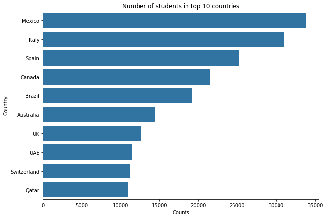

```python
#Top 10 countries of the number of students
plt.figure(figsize=[10,7])
color = sb.color_palette()[0]
sb.countplot(data = df, y = 'Country', color =color, order=df['Country'].value_counts().index[:10])
plt.title('Number of students in top 10 countries');
plt.xlabel('Counts');
```

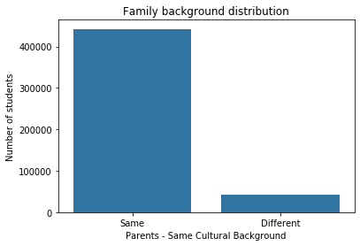

```python
color = sb.color_palette()[0]
sb.countplot(data = df, x = 'Parents - Same Cultural Background', color =color)
plt.title('Family background distribution');
plt.ylabel('Number of students');
```

From this previous distribution, Notice number of students having parents with same cultural background much higher than those having parents with different backgrounds.

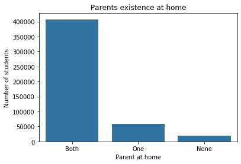

```python
color = sb.color_palette()[0]
sb.countplot(data = df, x = 'Parent at home',order=df['Parent at home'].value_counts().index, color =color)
plt.title('Parents existence at home');
plt.ylabel('Number of students');
```

Number of students having both parents at home is the highest

## Bivariate Exploration

> In this section, investigate relationships between pairs of variables in your data.

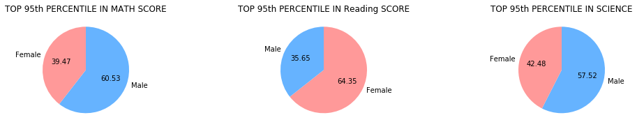

```python
df_95math=df[df['Math Score']>=df['Math Score'].quantile(.95)]
df_95reading=df[df['Reading Score']>=df['Reading Score'].quantile(.95)]
df_95science=df[df['Science Score']>=df['Science Score'].quantile(.95)]

color_set = ['#66b3ff','#ff9999']
plt.figure(figsize = [15, 9])

plt.subplots_adjust(wspace = 1.2)

plt.subplot(1, 3, 1)
plt.pie(df_95math['Gender'].value_counts(), labels=df_95math['Gender'].value_counts().index,startangle=90,counterclock=False,autopct='%.2f',colors=color_set)
plt.title('TOP 95th PERCENTILE IN MATH SCORE');

plt.subplot(1, 3, 2)
plt.pie(df_95reading['Gender'].value_counts(), labels=df_95reading['Gender'].value_counts().index,startangle=90,counterclock=False,autopct='%.2f',colors=color_set2)
plt.title('TOP 95th PERCENTILE IN Reading SCORE');

plt.subplot(1, 3, 3)
plt.pie(df_95science['Gender'].value_counts(), labels=df_95science['Gender'].value_counts().index,startangle=90,counterclock=False,autopct='%.2f',colors=color_set)
plt.title('TOP 95th PERCENTILE IN SCIENCE');
```

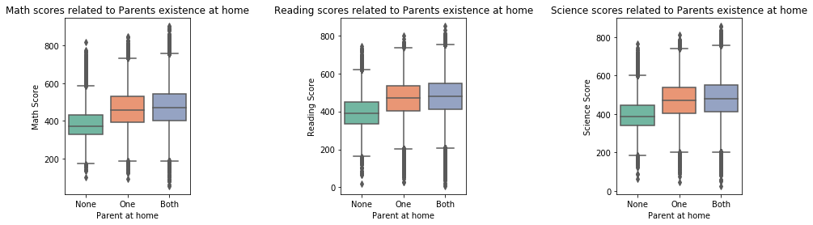

```python
plt.figure(figsize = [15, 4])
plt.subplots_adjust(wspace = 1.2)
order = ['None', 'One', 'Both']


plt.subplot(1, 3, 1)
sb.boxplot(x = df['Parent at home'], y = df['Math Score'], palette = 'Set2', order=order)
plt.title('Math scores related to Parents existence at home');

plt.subplot(1, 3, 2)
sb.boxplot(x = df['Parent at home'], y = df['Reading Score'], palette = 'Set2',order=order)
plt.title('Reading scores related to Parents existence at home');

plt.subplot(1, 3, 3)
sb.boxplot(x = df['Parent at home'], y = df['Science Score'], palette = 'Set2', order=order);
plt.title('Science scores related to Parents existence at home');
```

On average, the highest scoring can be seen of students with both parents

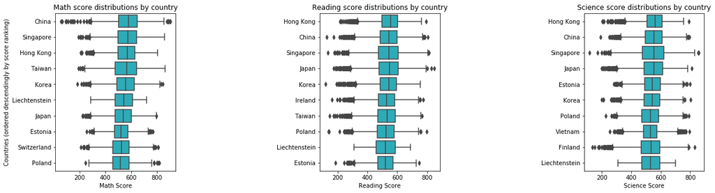

```python
plt.figure(figsize = [20, 5])
plt.subplots_adjust(wspace = 1.2) # adjust spacing between subplots, in order to show long country names nicely

math_score_country_order = df.groupby('Country')['Math Score'].mean().sort_values(ascending = False).index[:10]
reading_score_country_order = df.groupby('Country')['Reading Score'].mean().sort_values(ascending = False).index[:10]
science_score_country_order = df.groupby('Country')['Science Score'].mean().sort_values(ascending = False).index[:10]

plt.subplot(1, 3, 1)
sb.boxplot(x = df['Math Score'], y = df['Country'], order = math_score_country_order, color = sb.color_palette()[9]);
plt.ylabel('Countries (ordered descendingly by score ranking)')
plt.title('Math score distributions by country');

plt.subplot(1, 3, 2)
sb.boxplot(x = df['Reading Score'], y = df['Country'], order = reading_score_country_order, color = sb.color_palette()[9]);
plt.ylabel(''); # Remove the redundant label
plt.title('Reading score distributions by country');

plt.subplot(1, 3, 3)
sb.boxplot(x = df['Science Score'], y = df['Country'], order = science_score_country_order, color = sb.color_palette()[9]);
plt.ylabel(''); # Remove the redundant label
plt.title('Science score distributions by country');
```

Here, in decreasing order, we have rankings in the top 10 countries with the best-performing students, on average, for each of the three subjects. We're finding that:

> We can clearly see that it was no coincidence that exceptional students came from Asian countries , in particular China, Singapore and Hong Kong, as these are countries that rank 1st , 2nd or 3rd in all subjects. Other countries that were impressed were Lechtenstein, Poland and Estonia, as these countries ranked among the top 10 in Reading and Science and Mathematics.

> The box-and-wiskers plot allows us to see in part the outliers in the scores for each country. For example, we find that, although a number of Singapore students have achieved outstanding results in the field of mathematics, this is not to be considered "out-of-the-ordinary in the country 's perspective, but the outstanding results achieved in science can indeed be considered to be slightly out-of-ordinary.

> Other such findings may be made by selecting a country of interest and checking its distribution of scores, rankings and outlier distribution accordingly.

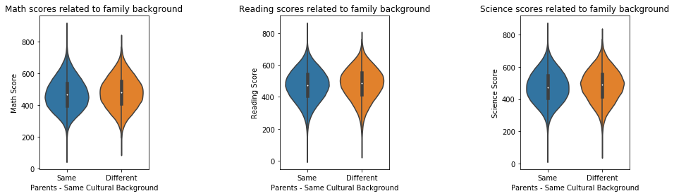

```python
plt.figure(figsize = [15, 4])
plt.subplots_adjust(wspace = 1.2)

plt.subplot(1, 3, 1)
sb.violinplot(x = df['Parents - Same Cultural Background'], y = df['Math Score'])
plt.title('Math scores related to family background');

plt.subplot(1, 3, 2)
sb.violinplot(x = df['Parents - Same Cultural Background'], y = df['Reading Score'])
plt.title('Reading scores related to family background');

plt.subplot(1, 3, 3)
sb.violinplot(x = df['Parents - Same Cultural Background'], y = df['Science Score']);
plt.title('Science scores related to family background');
```

Does the different birthplaces of parents affect student scores? As a result, we can't see any difference.

## Multivariate Exploration

> In this section, we will investigate the relationships between the interactions of three or more variables at the same time.

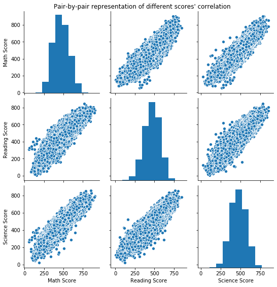

```python
grid = sb.pairplot(data = df, vars=["Math Score", "Reading Score", "Science Score"]);
grid.fig.suptitle("Pair-by-pair representation of different scores' correlation", y = 1.02);
```

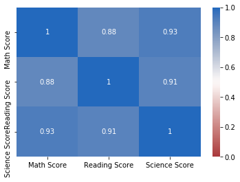

```python
sb.heatmap(data=df[["Math Score", "Reading Score", "Science Score"]].corr(), cmap = 'vlag_r',annot=True, vmin=0, vmax=1);
```

As it could be expected, there is a very strong and positive correlation between any pair of the three variables representing the scores of the three subjects. Therefore, the previous relationships between scores observed in the behaviour of many countries' students is justified.

### Conclusions

Exploring from the original problem, we got several conclusions as follows:

1. Students with their parents will have better study
2. The performance of girls in reading is better than that of boys. But the performance of boys in mathematics and science is better.
3. In the PISA test, the scores of Asian countries seem to be slightly higher.
4. Finally, there is a very strong and positive correlation between any pair of the three variables representing the score of the three subjects.

> At the end of your report, make sure that you export the notebook as an html file from the `File > Download as... > HTML` menu. Make sure you keep track of where the exported file goes, so you can put it in the same folder as this notebook for project submission. Also, make sure you remove all of the quote-formatted guide notes like this one before you finish your report!